# R-Workflow, Basic Datahandling, Challenges

10/9/2018

## Was machen wir heute?

1. Recap und Fragen
2. Workflow in R [streamlined!]
3. `dplyr` Tutorial
4. Anmerkungen zu den Daten
   - duplicates
   - missing data
   - data inflation
5. Exkurs: Clustering

## Recap und Fragen

## Recap und Fragen

- Bootcamps (alle auch auf Olat):
  - [bc1](https://htmlpreview.github.io/?https://github.com/lucienbaumgartner/ddj18/blob/master/src/bootcamps/bc1.html)
  - [bc2](https://htmlpreview.github.io/?https://github.com/lucienbaumgartner/ddj18/blob/master/src/bootcamps/bc2.html)
  - [bc3](https://htmlpreview.github.io/?https://github.com/lucienbaumgartner/ddj18/blob/master/src/bootcamps/bc3.html)

## Streamlined Workflow

## Streamlined Workflow

```bash
project
      |_src
          |_00-import-data.R
          |_01-clean-data.R
          |_...
      |_input
          |_data1.csv
          |_data2.xls
          |_...
      |_output
          |_plots
                |_0x-random-plot.png
                |_...
          |_00-imported-data.RData
          |_01-cleaned-data.RData
          |_...
```

## Advanced

Use symlinks to your cloud to store data remotely:

```bash
user$ ln -s ~/dropbox/folder/.../ ~/project/output
```

Danach könnt ihr einfach direkt in den output-Folder speichern

-> BABAAM, auf der Dropbox

Beispiel: https://github.com/lucienbaumgartner/ddj18

## FOCUS

1. ‘Forschungsfrage’ / ‘Hypothese’ / **educated guess**
2. WAS will ich herausfinden? (und wieso?)
3. WIE sieht mein Traumresultat aus (statistisch/visuell)?
4. WAS für Methoden brauche ich, WELCHE Daten kommen dazu infrage?
5. WIE muss meine Datenstruktur für meine Viz/meine Analysen aussehen?
6. WIE erreiche ich, dass meine Daten das gewünschte Format haben? -> workflow: welche steps muss ich durchlaufen
7. Braucht es Validitäts-checks?

Ihr solltet zu JEDEM ZEITPUNKT des Datenhandlings wissen, was ihr macht, wie eure Daten aussehen, und wie sie aussehen sollen.

## FOCUS

- **missing data**
  - bitte schaut genug früh, ob die Variablen, die euch interessieren auch genug Datenpunkte beinhalten … UND
- **not enough variance**
  - genug Varianz aufweisen, sodass eine Analyse überhaupt Sinn macht

## `dyplr` Tutorial

## `dyplr` Tutorial

https://cran.r-project.org/web/packages/dplyr/vignettes/dplyr.html

## Anmerkungen zu den Daten

## Anmerkungen zu den Daten

- Daten haben zwei Aggregations-Levels:
  - Personen (`persnum-lvl`)
    - bevoelkerung (main)
    - umzug
    - wegzug
    - zuzug
  - Gebäude (`geb`)
    - gebaeude
    - finanzen
    - wohnung

## Konsolidierte Datensätze

- POS:
  - Information zentralisiert abrufbar
  - weniger rekursives ge-joine -> weniger Fehler (!!!)
  - besseres Datenverständnis
- NEG:
  - grössere Objekte im Arbeitsspeicher -> SLOW
  - Fehler beim initialen joinen ziehen sich durch das ganze Projekt
- Counter:
  - Validitäts-checks
  - einfach parallelisierbar
  - subsets, subsets, subsets; ABER: Hypothesengeleitet und nicht strukturell bedingt

## Step-by-step

- [Import data](https://github.com/lucienbaumgartner/ddj18/blob/master/src/00-import-data.R)
- [Clean data](https://github.com/lucienbaumgartner/ddj18/blob/master/src/01-clean-data.R)
- [Join data](https://github.com/lucienbaumgartner/ddj18/blob/master/src/02-join-data.R)

## ACHTUNG

- **Personen kommen mehrfach vor**. Wieso?
  - Paneldaten: Sie kommen mind. 1x / Jahr vor
  - Falls sie wegziehen, zuziehen oder umziehen, *können* sie mehrfach vorkommen
- Na und?
  - Wenn ihr mit Mehrfachnennungen rechnet, dann müsst ihr das zumindest in der Methodenbox erwähnen
  - Wenn ihr nicht mit Mehrfachnennungen rechnen möchtet, dann müsst ihr euch überlegen, welche Observation ihr rausfiltert

## Mehrfachnennungen auf `persnum-lvl`

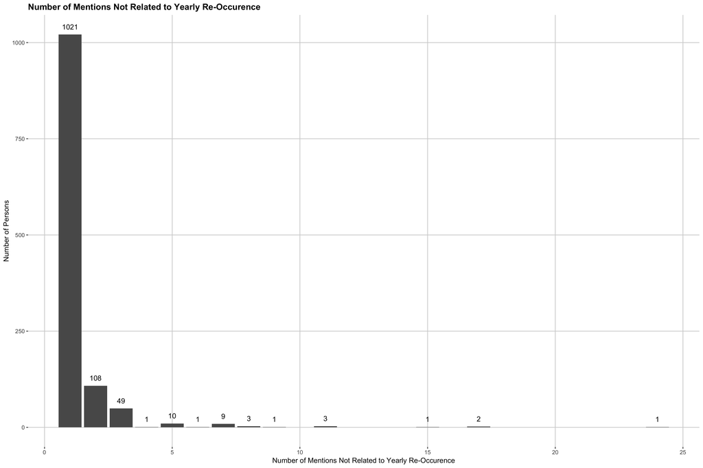

- [script](https://github.com/lucienbaumgartner/ddj18/blob/master/src/03-DISCLAIMER-challenges-pers.R)

## Mehrfachnennungen auf `persnum-lvl`

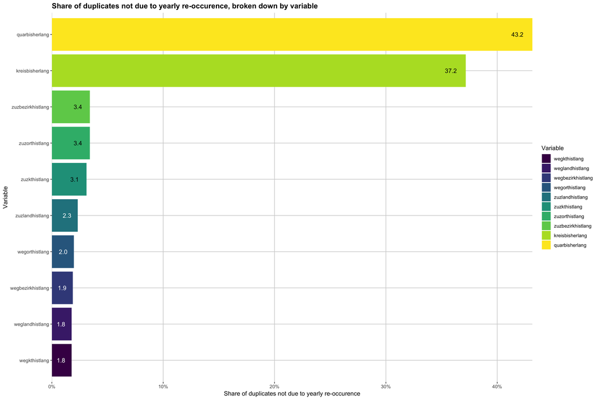

- [script](https://github.com/lucienbaumgartner/ddj18/blob/master/src/03-DISCLAIMER-challenges-pers.R)

## Missing data: `persnum-lvl` [INFLATED]

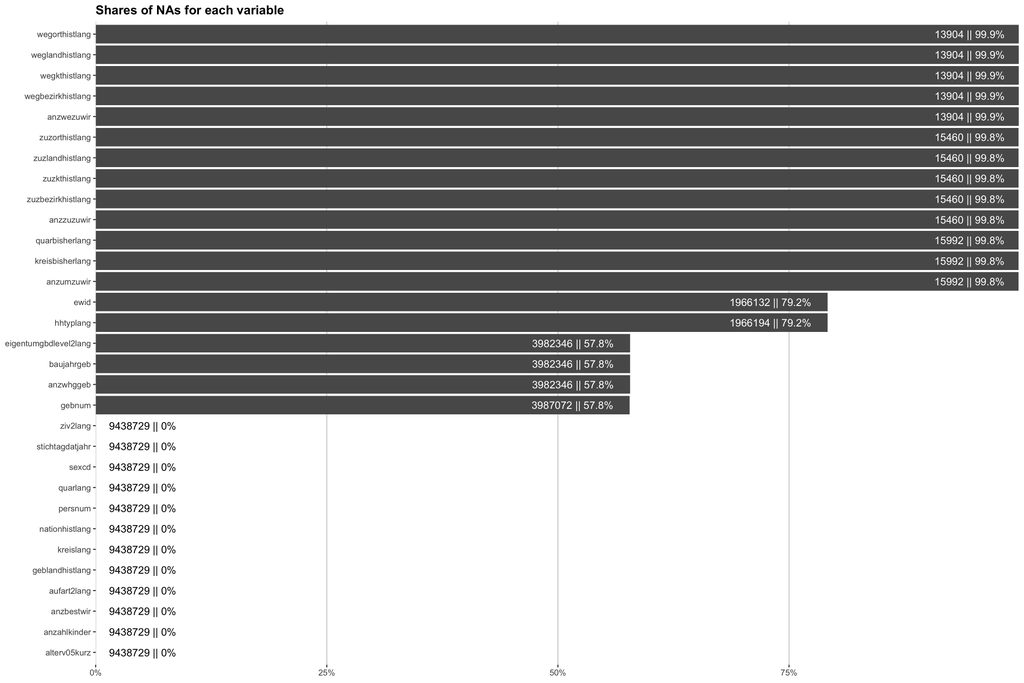

## Missing data: source

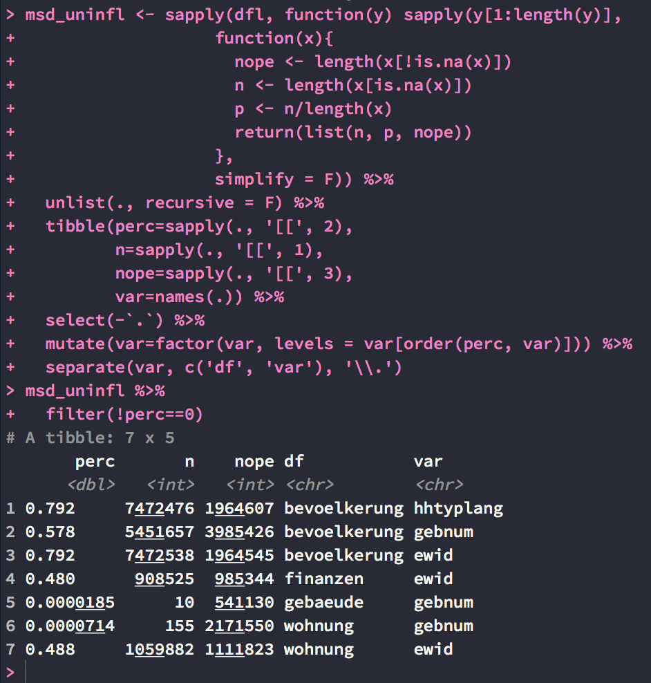

## Missing data

- [script](https://github.com/lucienbaumgartner/ddj18/blob/master/src/03-DISCLAIMER-challenges-pers.R)

## Exkurs: Clustering

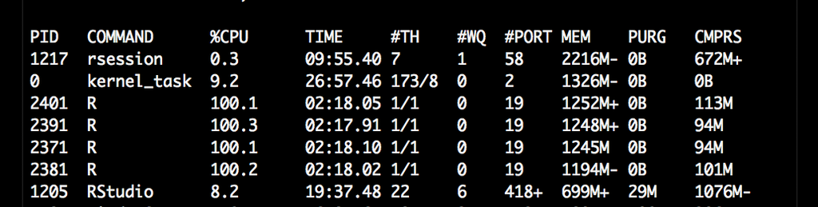

- Das Dataframe wird nach einer Schlüsselvariable auf verschiedene Kerne verteilt, wo jeweils parallel die gleichen Funktionen darüber laufen
- Vorteil: Speed! (NOT IN EVERY CASE, TOUGH)
- Alles, was ihr dafür braucht, ist das package `multidplyr`.

## Exkurs: Clustering

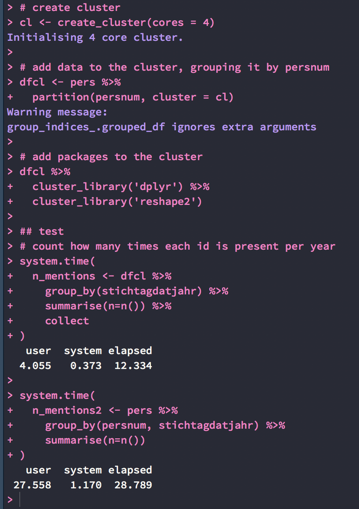

## Exkurs: Clustering :: Ressourcen

https://www.business-science.io/code-tools/2016/12/18/multidplyr.html

http://blog.aicry.com/multidplyr-dplyr-meets-parallel-processing/index.html

## Ressourcen

## Basics

- [Methodenleitbuch](https://github.com/lucienbaumgartner/ddj18/res/Chair_Uebungsbuch_2015.pdf)
- [DataCamp R Intro](https://campus.datacamp.com/courses/free-introduction-to-r/chapter-1-intro-to-basics-1?ex=1)
- [RegexBuddy](https://www.regular-expressions.info/)
- [dplyr cheatsheet](https://www.rstudio.com/wp-content/uploads/2015/02/data-wrangling-cheatsheet.pdf)
- [dplyr Intro](https://rpubs.com/justmarkham/dplyr-tutorial)
- [FT Visual Vocab](https://github.com/ft-interactive/chart-doctor/blob/master/visual-vocabulary/Visual-vocabulary.pdf)
- [Stack overflow](https://stackoverflow.com/)

## Extended

- [Plot Layouts](https://cran.r-project.org/web/packages/egg/vignettes/Ecosystem.html)
- [R Graph Gallery](https://www.r-graph-gallery.com/)
- [Tidying spatial data](http://strimas.com/r/tidy-sf/)
- [Working with missing data in area plots](https://mattmazur.com/2017/04/19/removing-gaps-from-stacked-area-charts-in-r/)
- [plotly for R](https://plotly-book.cpsievert.me/index.html)
- [Little Inspiration (Capstone Website)](https://lucienbaumgartner.github.io/capstone_webdev/)